# DSC595_001_A4_jshouse

John House PhD

# This assignment uses the gwas.RData file provided in Lecture 5

- you will need to load it into R. If it is in the same location as this homework, then you will not need a path
- i.e. load(“gwas.RData”) should work

```r
load("gwas.RData")
names(gwas)
```

```
 [1] "DATE ADDED TO CATALOG"      "PUBMEDID"
 [3] "FIRST AUTHOR"               "DATE"
 [5] "JOURNAL"                    "LINK"
 [7] "STUDY"                      "DISEASE/TRAIT"
 [9] "INITIAL SAMPLE SIZE"        "REPLICATION SAMPLE SIZE"
[11] "REGION"                     "CHR_ID"
[13] "CHR_POS"                    "REPORTED GENE(S)"
[15] "MAPPED_GENE"                "UPSTREAM_GENE_ID"
[17] "DOWNSTREAM_GENE_ID"         "SNP_GENE_IDS"
[19] "UPSTREAM_GENE_DISTANCE"     "DOWNSTREAM_GENE_DISTANCE"
[21] "STRONGEST SNP-RISK ALLELE"  "SNPS"
[23] "MERGED"                     "SNP_ID_CURRENT"
[25] "CONTEXT"                    "INTERGENIC"
[27] "RISK ALLELE FREQUENCY"      "P-VALUE"
[29] "PVALUE_MLOG"                "P-VALUE (TEXT)"
[31] "OR or BETA"                 "95% CI (TEXT)"
[33] "PLATFORM [SNPS PASSING QC]" "CNV"
[35] "MAPPED_TRAIT"               "MAPPED_TRAIT_URI"
[37] "STUDY ACCESSION"            "GENOTYPING TECHNOLOGY"
```

# Assignment 5 Q1

### How many different **Unique** Mapped Traits have been found on each Chromosome?

- Note: this is independent of cancer related traits
- Print a table to the screen by chromosome of this information

```r
gwas %>%
  mutate(CHR_ID = as.numeric(CHR_ID)) %>% ## convert chromosome to numeric so it sorts nicely and drops problem values
  group_by(CHR_ID) %>% ## set up the following operations to be conducted by group
  summarize(Mapped_Traits = n_distinct(MAPPED_TRAIT)) -> trait_table ## Since I need this object for Question 2, I'll assign it to an object to reuse
## print the table to output
trait_table %>% kbl(caption = "Number of Distinct Traits by Chromosome") %>%
  kable_styling(bootstrap_options = c("striped", "hover"), full_width = F)
```

Number of Distinct Traits by Chromosome

| CHR_ID | Mapped_Traits |
| --- | --- |
| 1 | 4091 |
| 2 | 3207 |
| 3 | 3218 |
| 4 | 2455 |
| 5 | 2575 |
| 6 | 3109 |
| 7 | 2338 |
| 8 | 2411 |
| 9 | 2298 |
| 10 | 2360 |
| 11 | 2885 |
| 12 | 2411 |
| 13 | 1603 |
| 14 | 1847 |
| 15 | 1938 |
| 16 | 2199 |
| 17 | 2521 |
| 18 | 1452 |
| 19 | 2739 |
| 20 | 1734 |
| 21 | 882 |
| 22 | 1250 |
| NA | 2361 |

NOTE: We could have removed NA’s using filter(CHR_ID %in% c(1:22)) after conversion to numeric

# Assignment 5 Q2

### Create a Bar Chart of those values by Chromosome

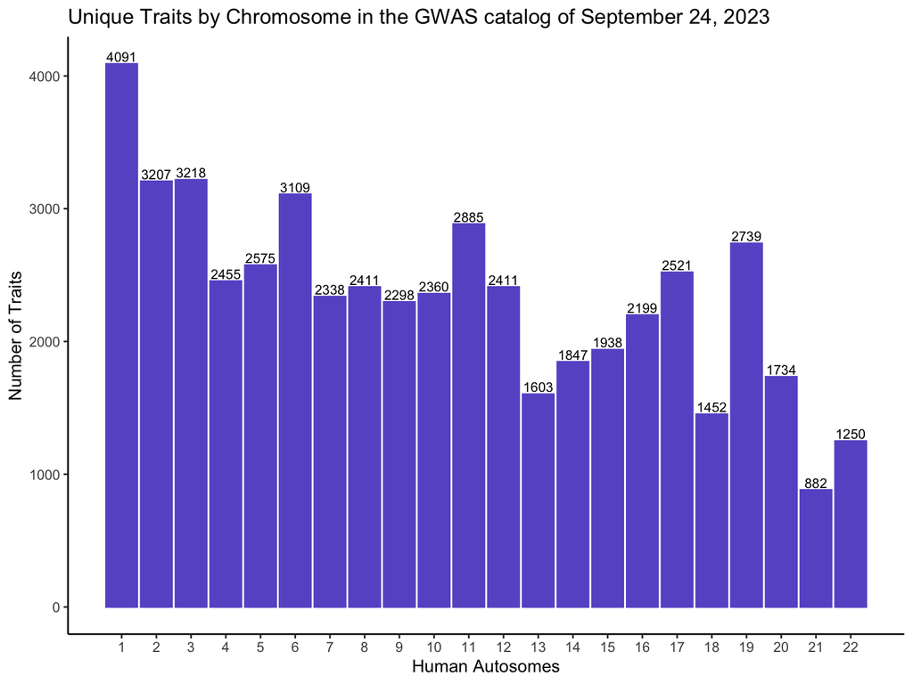

```r
library(ggplot2)

trait_table %>%
  ggplot(aes(x = CHR_ID, y = Mapped_Traits)) +
  geom_bar(stat = "identity", color = "slateblue", fill = "slateblue") +
  scale_x_continuous(breaks = 1:22) +
  xlab("Human Autosomes") +
  ylab("Number of Traits") +
  ggtitle("Unique Traits by Chromosome in the GWAS catalog of September 24, 2023")+
  geom_text(aes(label=Mapped_Traits), size = 3, position=position_dodge(width=0.9), vjust=-0.25) +
  theme_classic()
```

# Assignment 5 Q3

### What 5 Mapped_Trait contains the most unique SNPS associated with them in the gwas catalog

```r
gwas %>% group_by(MAPPED_TRAIT) %>%
  summarize(Unique_SNPS = n_distinct(SNPS)) %>%
  arrange(desc(Unique_SNPS)) %>%
  head(5) %>%
  kbl(caption = "The GWAS TRAIT with the most variants (SNPS) is 'body height'") %>%
  kable_styling(bootstrap_options = c("striped", "hover"), full_width = F)
```

The GWAS TRAIT with the most variants (SNPS) is ‘body height’

| MAPPED_TRAIT | Unique_SNPS |
| --- | --- |
| body height | 21954 |
| body mass index | 7717 |
| blood metabolite measurement | 6450 |
| educational attainment | 5230 |
| gut microbiome measurement | 5214 |

```r
## We could get the same thing with using slice_max and not have to sort with arrange() or use head()
gwas %>% group_by(MAPPED_TRAIT) %>%
  summarize(Unique_SNPS = n_distinct(SNPS)) %>%
  slice_max(Unique_SNPS, n = 5) %>%
  kbl(caption = "The GWAS TRAIT with the most variants (SNPS) is 'body height'") %>%
  kable_styling(bootstrap_options = c("striped", "hover"), full_width = F)
```

The GWAS TRAIT with the most variants (SNPS) is ‘body height’

| MAPPED_TRAIT | Unique_SNPS |
| --- | --- |
| body height | 21954 |
| body mass index | 7717 |
| blood metabolite measurement | 6450 |
| educational attainment | 5230 |
| gut microbiome measurement | 5214 |

# Assignment 5 Q4

### What MAPPED_GENE has the most **unique** gwas MAPPED_TRAITS associated with it?

- Print those unique traits to the screen along with the number of unique variants for each trait as a table

#### This time we need to group on the genes and collect trait info first to find the GENE of interest

```r
gwas %>% group_by(MAPPED_GENE) %>%
  summarize(Traits_Per_Gene = n_distinct(MAPPED_TRAIT)) %>%
  slice_max(Traits_Per_Gene, n = 2)
```

```
# A tibble: 2 × 2
  MAPPED_GENE Traits_Per_Gene
  <chr>                 <int>
1 ""                     3045
2 "CFH"                  1054
```

### This resulted in the traits without a Mapped Gene being the highest!

#### So lets look at the top 2 to get our gene of interest

```r
gwas %>% group_by(MAPPED_GENE) %>%
  summarize(Traits_Per_Gene = n_distinct(MAPPED_TRAIT)) %>%
  slice_max(n = 2,Traits_Per_Gene)
```

```
# A tibble: 2 × 2
  MAPPED_GENE Traits_Per_Gene
  <chr>                 <int>
1 ""                     3045
2 "CFH"                  1054
```

### Now we see our gene is CFH so we can answer part II of the question

- Print those unique traits to the screen along with the number of unique variants for each trait as a table

# Question 4 continued

#### Now we can filter on just the CFH gene

```r
gwas %>%
  dplyr::filter(MAPPED_GENE == "CFH") %>% ## select only records with our gene of interest
  group_by(MAPPED_TRAIT) %>%
  summarise(Trait_Variants = n_distinct(SNPS)) %>%
  arrange(desc(Trait_Variants)) ## Not asked for but nice to see
```

```
# A tibble: 1,054 × 2
   MAPPED_TRAIT                                                   Trait_Variants
   <chr>                                                                   <int>
 1 protein measurement                                                        45
 2 response to bronchodilator, FEV/FEC ratio                                  21
 3 blood protein measurement                                                  16
 4 age-related macular degeneration                                           13
 5 complement factor H measurement                                            11
 6 properdin measurement                                                       5
 7 atrophic macular degeneration, age-related macular degenerati…              4
 8 complement factor H-related protein 2 measurement                           3
 9 complement factor H-related protein 5 measurement                           3
10 low density lipoprotein cholesterol measurement                             3
# ℹ 1,044 more rows
```

### This shows us all the 1054 traits associated with variants in and near CFH. With the trait **protein measurement** having 45 variants near CFH associated with it.

#### You might have printed every one, but the default print from a large data.frame from the tidyverse is to print the first 10 or so as shown. You may also have not arranged the order to see anything but the single variant for a bunch of traits. That is fine too.